# 161331 Tutorial 9: Simple Random-Effect Model

Adam N. H. Smith

```r
library(ggplot2)
library(tidyverse)
## If you don’t have it installed already, install.packages("faraway")
library(faraway)
theme_set(theme_bw())
```

Note: you can download the .Rmd file using the ‘code’ button on the top right.

# 1 Tutorial: Analysis of pulp data

See original tutorial page.

# 2 Exercise

A nutritionist conducted a study to assess the nutritional status of children enrolled in early childhood centres (ECC) in a city. There were a total of 6649 children enrolled in ECCs, distributed among 40 centres (ECCs). To collect the information, she randomly selected 5 centres and then randomly selected a number of children in each centre. The number of children observed in each centre were not the same.

Among other characteristics, she collected information on children’s body mass index (BMI). A question of interest was whether the centre (ECC) factor had an influence on BMI.

The dataset is contained in a file named`BMI.txt`, which is available on Stream and via github.

**a) Why would we treat the factor `ecc` (centre) as random in this example?**

*Because the 5 centres in the dataset represent a sample from a “population” of centres, and the nutritionist is not so interested in the effects of being in these 5 particular centres, but rather about how much variation there is in the whole population of centres.*

**b) Import and inspect the data. Checking the number of factor levels and number of replicates per level.**

```r
bmi <- read.table(
  "https://raw.githubusercontent.com/anhsmith/161331/main/data/BMI.txt",
  header=TRUE
  )
```

```r
summary(bmi)
```

```
##      ecc                 BMI
##  Length:43          Min.   :10.99
##  Class :character   1st Qu.:14.04
##  Mode  :character   Median :15.03
##                     Mean   :15.10
##                     3rd Qu.:16.25
##                     Max.   :20.04
```

```r
str(bmi)
```

```
## 'data.frame':    43 obs. of  2 variables:
##  $ ecc: chr  "A" "A" "A" "A" ...
##  $ BMI: num  15.6 16.7 15.3 14.9 14.2 ...
```

```r
table(bmi$ecc)
```

```
##
##  A  B  C  D  E
##  7  8  8 10 10
```

*The variable `ecc` is a factor with 5 levels, and there are different numbers of observations per level (7 observations at ECC A, 8 at ECC B, etc.)*

**c) Produce some descriptive statistics, specifically the mean and standard deviation, for each group.**

```r
bmi %>%
  group_by(ecc) %>%
  summarise(Mean = mean(BMI), SD= sd(BMI))
```

| ecc | Mean | SD |
| --- | --- | --- |
| A | 15.37286 | 0.8166948 |
| B | 15.01875 | 2.0639521 |
| C | 15.49000 | 1.2719164 |
| D | 14.61300 | 2.7322886 |
| E | 15.13800 | 2.1331604 |

*The means are similar among ECCs. For the sd, there is less variation in ECCs A and C than in the others.*

**d) Summarise the data per group with a graph. What can be said about intraclass correlation?**

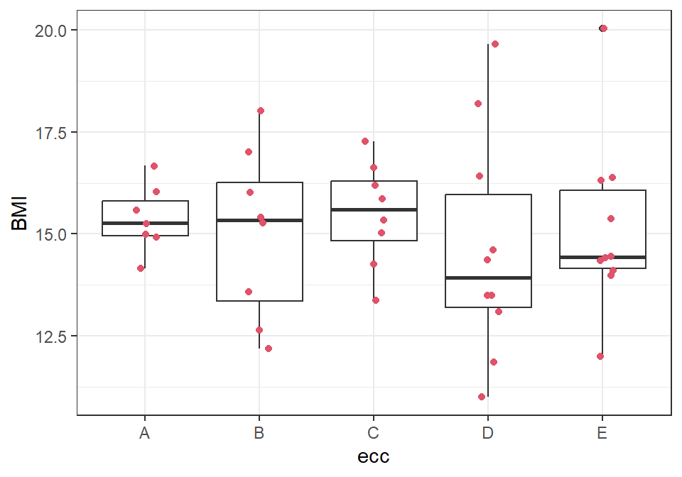

```r
ggplot(data=bmi) +
  geom_boxplot(mapping=aes(x=ecc, y=BMI)) +
  geom_jitter(aes(x=ecc, y=BMI),width = 0.1, col = 2)
```

*From the plot above, there doesn’t seem to be very high intraclass correlation (ICC). That is, variability among groups is small compared to variability within groups. We will calculate the ICC coefficient later.*

**e) Estimate the variance components using the ANOVA method.**

Remember the ANOVA estimate of variance components are: $\hat{\sigma}^2=MS_{Error}$ and $\hat{\sigma}_{\alpha}^2= \frac{MS_{Group} - MS_{Error}}{n}$, where the denominator $n$ is the number of observations per group.

**Remark on the non-balanced design.** In this example, the design is not balanced; that is, the number of observations varies among the groups ($n_i$). This causes some issues. Therefore, to estimate $\hat{\sigma}_{\alpha}^2$, we will replace $n$ in the denominator by $k_1.$

$\hat{\sigma}_{\alpha}^2= \frac{MS_{Group} - MS_{Error}}{k_1}$, where

$k_1=\frac{1}{I-1}[N-\frac{\sum_i n_i^2}{N}]$, where $N$ is the total number of observations, $I$ is the number of groups, and $n_i$ is the number of observations in group $i$.

*Fitting the conventional one-way ANOVA model.*

```r
aov.bmi <-
  lm(BMI ~ ecc, data = bmi) %>%
  anova %>%
  print
```

```
## Analysis of Variance Table
##
## Response: BMI
##           Df  Sum Sq Mean Sq F value Pr(>F)
## ecc        4   4.177  1.0442  0.2588 0.9024
## Residuals 38 153.288  4.0339
```

*The ANOVA variance components estimates are:*

```r
# sigma2 = MS_Residulas = 4.03

# sigma2_ecc
ni <- c(7,8,8,10,10)
k1 = ( sum(ni) - sum(ni^2) / sum(ni) ) / (5-1)
sigma2ecc = (1.04442 - 4.0339)/k1
sigma2ecc
```

```
## [1] -0.3493142
```

*Oops! a negative estimate for a variance component!*

*In addition to the difficulty imposed by the unbalanced design in estimating* $\sigma_{group}^2$*, the use of ANOVA method produced a negative estimate. REML method is a better alternative.*

**f) Fit a one-way random-effect linear model using `lmer()` from `lme4` package. What are the REML estimates of the variance components? Compare them with the ANOVA estimates.**

```r
library(lme4)
bmi_reml <- lmer(BMI ~ ( 1 | ecc ), data=bmi)
```

```
## boundary (singular) fit: see help('isSingular')
```

```r
summary(bmi_reml)
```

```
## Linear mixed model fit by REML ['lmerMod']
## Formula: BMI ~ (1 | ecc)
##    Data: bmi
##
## REML criterion at convergence: 178.5
##
## Scaled residuals:
##      Min       1Q   Median       3Q      Max
## -2.12131 -0.54870 -0.03483  0.59266  2.55262
##
## Random effects:
##  Groups   Name        Variance Std.Dev.
##  ecc      (Intercept) 0.000    0.000
##  Residual             3.749    1.936
## Number of obs: 43, groups:  ecc, 5
##
## Fixed effects:
##             Estimate Std. Error t value
## (Intercept)  15.0974     0.2953   51.13
## optimizer (nloptwrap) convergence code: 0 (OK)
## boundary (singular) fit: see help('isSingular')
```

*The REML variance components estimates are*

$\hat \sigma_{ecc}^2=0$ and

$\hat \sigma^2=3.75$.

*These are different to the estimates obtained via ANOVA method.*

*This suggests that all variation in the data is due to the variation within groups. Thus, the intraclass correlation coefficient will be zero.*

**g) Calculate the intraclass correlation coefficient.**

```r
0/(0+3.75)
```

```
## [1] 0
```

**h) Test the null hypothesis $H_0: \sigma^2_{ecc} =0$ (with the alternative hypothesis $H_0: \sigma^2_{ecc} > 0$). Write down your conclusion.**

*As our estimate for $\sigma^2_{ecc}$ is zero, it is obvious that we won’t reject the null hypothesis.*

*Our reference model is `bmi.reml`*

```r
summary(bmi_reml)$logLik
```

```
## 'log Lik.' -89.22812 (df=3)
```

```r
# save it as a number
bmi_reml_logLik <- as.numeric(summary(bmi_reml)$logLik)
bmi_reml_logLik
```

```
## [1] -89.22812
```

```r
#Fitting the nested model (no random effect)
detach(package:lme4, unload=TRUE)
library(nlme)
bmi_null <- gls(BMI ~ 1, data=bmi)
bmi_null$logLik
```

```
## [1] -89.22812
```

*The log likelihoods are exactly the same!*

*The likelihood ratio test statistic is*

```r
#G2 = 2(l(R) - l(N))
G2 = 2*(bmi_reml_logLik - bmi_null$logLik)
G2
```

```
## [1] -2.842171e-14
```

*The p-value is given by:*

```r
0.5 * pchisq(G2, df=0, lower.tail = FALSE) +
0.5 * pchisq(G2, df=1, lower.tail = FALSE)
```

```
## [1] 1
```

*As expected, we don’t reject the null hypothesis. Our conclusion is that we have no evidence of any variability in average BMI among early childhood centres.*